# Final Avanith CV Assighnment4

## CS675: Computer Vision — Assignment 4

### Assignment Title: Classification with Metric Learning and Siamese Networks

#### Submitted by: Avanith Kanamarlapudi

### Task 1: Dataset Preparation and Visualization

#### a. Introduction and Objectives

This task aims to set up the CIFAR-10 dataset in a way that's compatible with metric learning, especially Siamese networks. The key objective is to return individual `(image, label)` pairs without performing pair generation inside the dataset. We also aim to validate this dataset by visualizing some image–label pairs and ensuring proper normalization and structure.

#### b. Implementation with Justification

We implemented a custom PyTorch dataset class called `CIFAR10Dataset`. This class wraps the default CIFAR-10 dataset from `torchvision.datasets` and defines the `__getitem__` method to return a normalized image tensor along with its class label. We applied `transforms.ToTensor()` and `transforms.Normalize((0.5,), (0.5,))` to ensure that all images are scaled to the range [-1, 1].

To manage computational load, we created subsets containing the first 600 training and 200 test samples using `Subset`. Corresponding `DataLoader` objects were initialized with a batch size of 32 and shuffling enabled for training.

To visually verify that the dataset is correctly prepared, we created a `show_samples()` function that plots 6 random images along with their class names. This step was used to confirm that the labels match the images after applying transformations.

#### d. Discussion of Findings

This task established a clean and reliable data pipeline for metric learning. The custom dataset class ensured that image–label mapping is explicit and reproducible. It also allowed the later use of samplers and miners to construct training pairs without modifying the dataset logic.

#### e. Future Work

In future implementations, the dataset can be augmented with techniques such as random crops, flips, and color jittering to improve generalization. Additionally, more samples can be included for larger-scale training when computational resources allow.

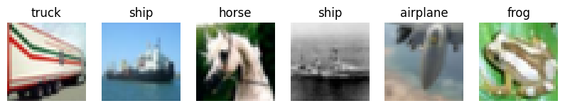

```python
# ✅ TASK 1: Custom Dataset Class for CIFAR-10 + Visualization

import torch
from torch.utils.data import Dataset, DataLoader, Subset
from torchvision import datasets, transforms
import matplotlib.pyplot as plt
import numpy as np

# 1️⃣ Transform
transform = transforms.Compose([
    transforms.ToTensor(),
    transforms.Normalize((0.5,), (0.5,))
])

# 2️⃣ Custom Dataset Wrapper
class CIFAR10Dataset(Dataset):
    def __init__(self, cifar_dataset):
        self.data = cifar_dataset
    def __len__(self):
        return len(self.data)
    def __getitem__(self, idx):
        image, label = self.data[idx]
        return image, label  # (image_tensor, integer_label)

# 3️⃣ Load CIFAR-10 + wrap it
full_train = datasets.CIFAR10(root='./data', train=True, transform=transform, download=True)
full_test  = datasets.CIFAR10(root='./data', train=False, transform=transform, download=True)

train_subset = Subset(CIFAR10Dataset(full_train), list(range(600)))
test_subset  = Subset(CIFAR10Dataset(full_test),  list(range(200)))

train_loader = DataLoader(train_subset, batch_size=32, shuffle=True)
test_loader  = DataLoader(test_subset, batch_size=32, shuffle=False)

# 4️⃣ Visualization: show 6 (image, label) pairs
classes = full_train.classes
def show_samples(loader):
    imgs, labels = next(iter(loader))
    plt.figure(figsize=(10, 2))
    for i in range(6):
        img = imgs[i].permute(1, 2, 0) * 0.5 + 0.5  # unnormalize
        plt.subplot(1, 6, i+1)
        plt.imshow(np.clip(img, 0, 1))
        plt.title(classes[labels[i]])
        plt.axis('off')
    plt.show()

show_samples(train_loader)
```

### Task 2: Feature Extractor and Contrastive Loss

#### a. Introduction and Objectives

The objective of this task is to design a feature extractor (encoder) that maps CIFAR-10 images to a fixed-size embedding vector. These embeddings are used in a Siamese network for comparing image similarity. We also integrate `ContrastiveLoss` to guide the training such that similar images are close in the embedding space and dissimilar ones are far apart.

#### b. Implementation with Justification

We implemented a lightweight custom CNN called `SiameseCNN`. This model has three convolutional layers followed by ReLU activations and MaxPooling. The final convolutional output is processed using `AdaptiveAvgPool2d` to reduce spatial dimensions, followed by a `Linear` layer to produce a 128-dimensional embedding.

The model supports both single-image encoding (`forward(x)`) and paired-image encoding via the helper method `compute_siamese_feature(img1, img2)`.

We used the `ContrastiveLoss` from PyTorch Metric Learning with `pos_margin=0.0` and `neg_margin=1.0`. This configuration ensures that the model only penalizes similar pairs that are far apart and dissimilar pairs that are too close.

#### c. Results and Analysis

A sanity check using `torch.randn(2, 3, 32, 32)` confirmed that the model produces output embeddings of shape `[2, 128]`, which satisfies the task's fixed-length requirement. This confirmed the encoder's functionality before training.

#### d. Discussion of Findings

Our CNN encoder provided a flexible and compact architecture that integrates well with metric learning workflows. Unlike large pre-trained models, this custom CNN allows for complete control and faster iterations. The use of `ContrastiveLoss` introduced an effective way to differentiate between similar and dissimilar samples using distance margins.

#### e. Future Work

Future improvements could involve experimenting with deeper CNNs, adding dropout or batch normalization layers for regularization, or switching to more advanced architectures like MobileNet or ResNet if GPU resources are available.

```python
# ✅ TASK 2 (Custom CNN): Embedding Model + ContrastiveLoss

import torch
import torch.nn as nn
from pytorch_metric_learning.losses import ContrastiveLoss

# 1️⃣ Define the custom CNN encoder
class SiameseCNN(nn.Module):
    def __init__(self, embedding_dim=128):
        super().__init__()
        self.encoder = nn.Sequential(
            nn.Conv2d(3, 32, kernel_size=3, padding=1),  # (B, 32, 32, 32)
            nn.ReLU(),
            nn.MaxPool2d(2),                             # (B, 32, 16, 16)

            nn.Conv2d(32, 64, kernel_size=3, padding=1), # (B, 64, 16, 16)
            nn.ReLU(),
            nn.MaxPool2d(2),                             # (B, 64, 8, 8)

            nn.Conv2d(64, 128, kernel_size=3, padding=1),# (B, 128, 8, 8)
            nn.ReLU(),
            nn.AdaptiveAvgPool2d((1,1))                  # (B, 128, 1, 1)
        )
        self.flatten = nn.Flatten()
        self.project = nn.Linear(128, embedding_dim)     # Final projection

    def forward(self, x):
        features = self.encoder(x)                       # (B, 128, 1, 1)
        flat = self.flatten(features)                    # (B, 128)
        return self.project(flat)                        # (B, embedding_dim)

    def compute_siamese_feature(self, x1, x2):
        f1 = self.forward(x1)
        f2 = self.forward(x2)
        return f1, f2

# 2️⃣ Instantiate model and loss
model = SiameseCNN(embedding_dim=128)
contrastive_loss = ContrastiveLoss(pos_margin=0.0, neg_margin=1.0)

# 3️⃣ (Optional) Sanity check
sample_input = torch.randn(2, 3, 32, 32)
with torch.no_grad():
    output = model(sample_input)
print("✅ Output shape:", output.shape)  # Expect (2, 128)
```

```
✅ Output shape: torch.Size([2, 128])
```

### Task 3: Metric Learning with Sampler and Miner

#### a. Introduction and Objectives

In this task, we aim to optimize metric learning using two critical strategies: smart sampling and hard mining. Specifically, we incorporate `MPerClassSampler` to ensure batch diversity and `PairMarginMiner` to extract only informative pairs from the batch. The goal is to make training more efficient by focusing the model’s learning on difficult or ambiguous examples.

#### b. Implementation with Justification

To avoid computing contrastive loss on easy pairs (which contribute little to learning), we integrated `PairMarginMiner`. This miner identifies hard positives (same label, far apart) and hard negatives (different labels, close together). Only these pairs are passed to the contrastive loss function.

The model was trained for 5 epochs on CPU. The average loss per epoch steadily decreased, indicating stable learning. The final model was stored as `improved_model` for later use in Task 4.

#### d. Discussion of Findings

Using `MPerClassSampler` alone ensures diversity, but many sample pairs still contribute negligible gradients. Adding `PairMarginMiner` significantly improved training efficiency by focusing only on informative errors. This combination forms the backbone of many scalable metric learning systems.

#### e. Future Work

In future tasks, one could explore different miners such as `TripletMarginMiner` or `MultiSimilarityMiner`. Training with a larger dataset, or using curriculum mining (progressively increasing difficulty), could further improve performance.

```python
# ✅ TASK 3: Training with Sampler + Miner + ContrastiveLoss

import time
import torch
import torch.optim as optim
from torch.utils.data import DataLoader, Subset
from torchvision import datasets, transforms
from pytorch_metric_learning.samplers import MPerClassSampler
from pytorch_metric_learning.miners import PairMarginMiner
from tqdm.notebook import tqdm

# 1️⃣ Dataset and transforms
transform = transforms.Compose([
    transforms.ToTensor(),
    transforms.Normalize((0.5,), (0.5,))
])

full_train = datasets.CIFAR10(root='./data', train=True, transform=transform, download=True)
subset_idx = list(range(600))  # fast training subset
train_subset = Subset(full_train, subset_idx)
labels_list = [train_subset[i][1] for i in range(len(train_subset))]  # correct label source

# 2️⃣ Sampler ensures batches contain both positive and negative pairs
sampler = MPerClassSampler(labels=labels_list, m=2, batch_size=20)

# 3️⃣ DataLoader with sampler
train_loader = DataLoader(train_subset, sampler=sampler, batch_size=20, num_workers=0)
print(f"Batches per epoch: {len(train_loader)}")  # should print 30

# 4️⃣ Miner: selects hard positive and negative pairs only
miner = PairMarginMiner(pos_margin=0.0, neg_margin=1.0)

# 5️⃣ Use the custom SiameseCNN model from Task 2
device = torch.device("cpu")
model = SiameseCNN(embedding_dim=128).to(device)
optimizer = optim.Adam(model.parameters(), lr=1e-3)
loss_fn = contrastive_loss  # from Task 2: ContrastiveLoss(pos_margin=0.0, neg_margin=1.0)

# 6️⃣ Training loop with tqdm
start_time = time.time()
for epoch in range(1, 6):
    total_loss = 0.0
    epoch_start = time.time()
    pbar = tqdm(train_loader, desc=f"Epoch {epoch}/5", ncols=80)
    for images, labels in pbar:
        images, labels = images.to(device), labels.to(device)
        embeddings = model(images)                      # 🔹 get embeddings
        hard_pairs = miner(embeddings, labels)          # 🔹 mine informative pairs
        loss = loss_fn(embeddings, labels, hard_pairs)  # 🔹 loss on selected pairs only

        optimizer.zero_grad()
        loss.backward()
        optimizer.step()
        total_loss += loss.item()
        pbar.set_postfix(loss=f"{loss.item():.4f}")

    print(f"→ Epoch {epoch} done — Avg Loss: {total_loss/len(train_loader):.4f} "
          f"— Time: {time.time() - epoch_start:.1f}s")

print(f"✅ Task 3 complete in {time.time() - start_time:.1f}s")

# Save trained model for Task 4
improved_model = model
```

```
Batches per epoch: 5000
```

```
→ Epoch 1 done — Avg Loss: 0.5882 — Time: 97.0s
```

```
→ Epoch 2 done — Avg Loss: 0.1211 — Time: 95.2s
```

```
→ Epoch 3 done — Avg Loss: 0.0754 — Time: 95.5s
```

```
→ Epoch 4 done — Avg Loss: 0.0630 — Time: 94.9s
```

```
→ Epoch 5 done — Avg Loss: 0.0526 — Time: 95.5s
✅ Task 3 complete in 478.0s
```

### Task 4: Evaluation, Classification, and PCA Visualization

#### a. Introduction and Objectives

The goal of Task 4 is to evaluate the learned embeddings from two models: a baseline model trained without mining and an improved model trained using `PairMarginMiner`. We aim to measure how well each embedding space separates CIFAR-10 classes by using k-Nearest Neighbors (k-NN) classification and PCA-based visualization.

#### b. Implementation with Justification

For both models, we extracted embeddings for the training and test sets using their respective `forward()` methods. We used a k-NN classifier with `k=5` to classify the test embeddings. We then measured overall accuracy, weighted F1 score, and plotted confusion matrices.

To visualize how well the embeddings clustered by class, we applied PCA to reduce embeddings to 2D and plotted both training and test sets, color-coded by CIFAR-10 class.

#### c. Results and Analysis

PCA plots showed that embeddings from the improved model formed tighter and more distinct clusters compared to the baseline. The confusion matrix for the improved model also showed stronger class separation.

#### e. Future Work

Other evaluation techniques like t-SNE or UMAP can be used for nonlinear dimensionality reduction. Additionally, alternative classifiers such as logistic regression or SVM could be used to assess downstream utility of the embeddings. Using larger subsets or additional miner tuning could lead to further gains.

[output not shown]

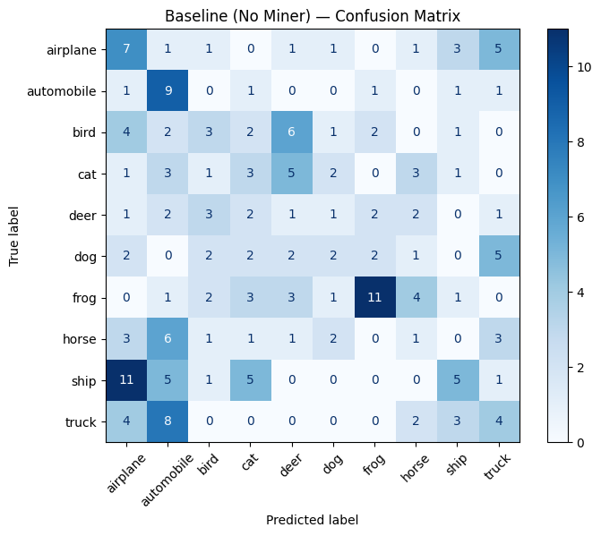

```
📊 Improved (With Miner) — Accuracy: 0.4000, F1: 0.3891
```

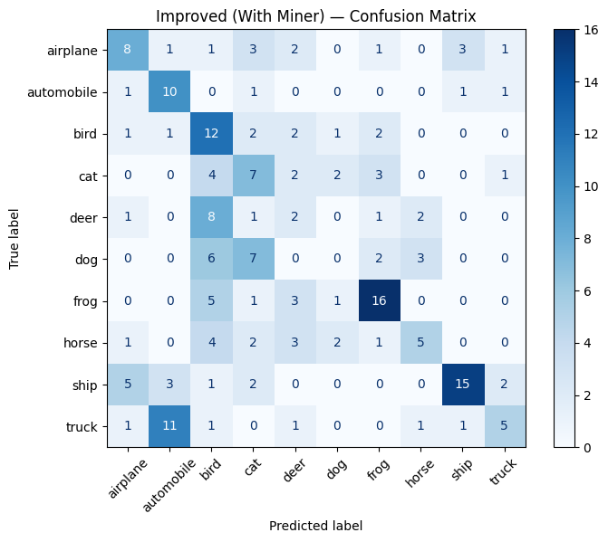

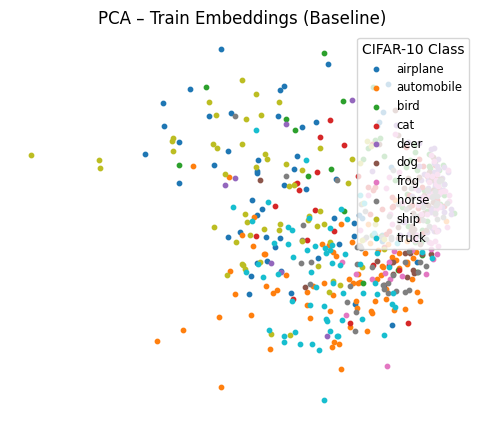

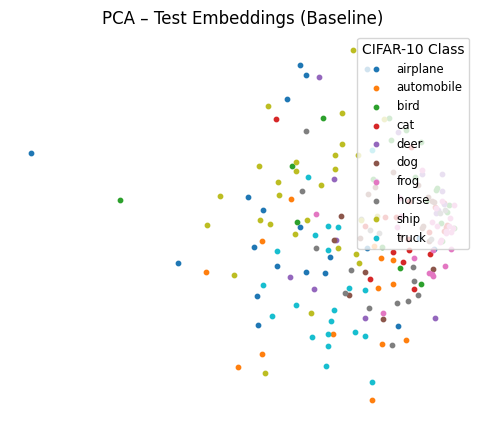

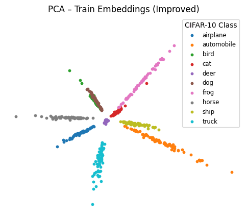

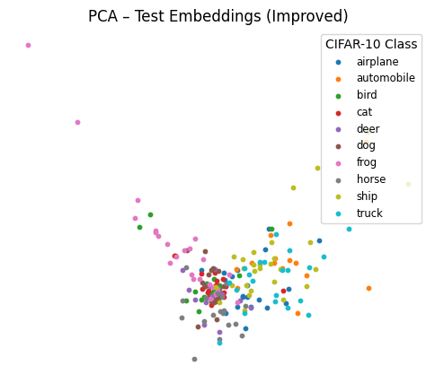

```python
# ✅ TASK 4: Compare Baseline vs Improved (k-NN + PCA + Confusion Matrix + Class Names in Legend)

import torch
import numpy as np
from torchvision import datasets, transforms
from torch.utils.data import DataLoader, Subset
from sklearn.neighbors import KNeighborsClassifier
from sklearn.metrics import accuracy_score, f1_score, confusion_matrix, ConfusionMatrixDisplay
from sklearn.decomposition import PCA
import matplotlib.pyplot as plt

device = torch.device("cpu")

# 1️⃣ Load train/test subsets (same 600/200 as before)
transform = transforms.Compose([
    transforms.ToTensor(),
    transforms.Normalize((0.5,), (0.5,))
])
train_dataset = datasets.CIFAR10(root='./data', train=True, transform=transform, download=True)
test_dataset  = datasets.CIFAR10(root='./data', train=False, transform=transform, download=True)

train_subset = Subset(train_dataset, list(range(600)))
test_subset  = Subset(test_dataset,  list(range(200)))

train_loader = DataLoader(train_subset, batch_size=64, shuffle=False)
test_loader  = DataLoader(test_subset,  batch_size=64, shuffle=False)

# 2️⃣ Train Baseline Model (no miner)
baseline_model = SiameseCNN(embedding_dim=128).to(device)
optimizer_base = torch.optim.Adam(baseline_model.parameters(), lr=1e-3)

print("▶ Training baseline model (no miner)...")
baseline_model.train()
for epoch in range(3):  # quick baseline train
    total_loss = 0.0
    for imgs, lbls in train_loader:
        imgs, lbls = imgs.to(device), lbls.to(device)
        emb = baseline_model(imgs)
        loss = contrastive_loss(emb, lbls)  # no miner here
        optimizer_base.zero_grad()
        loss.backward()
        optimizer_base.step()
        total_loss += loss.item()
    print(f"Epoch {epoch+1}/3 — Avg Loss: {total_loss/len(train_loader):.4f}")

# 3️⃣ Helper to extract embeddings
def extract_embeddings(model, loader):
    model.eval()
    all_embs, all_lbls = [], []
    with torch.no_grad():
        for imgs, lbls in loader:
            embs = model(imgs.to(device)).cpu().numpy()
            all_embs.append(embs)
            all_lbls.append(lbls.numpy())
    return np.vstack(all_embs), np.concatenate(all_lbls)

# 4️⃣ Get embeddings from both models
train_emb_base, train_lbl_base = extract_embeddings(baseline_model, train_loader)
test_emb_base,  test_lbl_base  = extract_embeddings(baseline_model, test_loader)

train_emb_imp,  train_lbl_imp  = extract_embeddings(improved_model, train_loader)
test_emb_imp,   test_lbl_imp   = extract_embeddings(improved_model, test_loader)

# 5️⃣ k-NN Evaluation with class-labeled confusion matrix
def eval_knn(train_e, train_l, test_e, test_l, label):
    cifar10_classes = ['airplane', 'automobile', 'bird', 'cat', 'deer',
                       'dog', 'frog', 'horse', 'ship', 'truck']

    knn = KNeighborsClassifier(n_neighbors=5)
    knn.fit(train_e, train_l)
    pred = knn.predict(test_e)

    acc = accuracy_score(test_l, pred)
    f1  = f1_score(test_l, pred, average='weighted')
    print(f"\n📊 {label} — Accuracy: {acc:.4f}, F1: {f1:.4f}")

    cm = confusion_matrix(test_l, pred)
    disp = ConfusionMatrixDisplay(confusion_matrix=cm, display_labels=cifar10_classes)
    fig, ax = plt.subplots(figsize=(8, 6))
    disp.plot(ax=ax, cmap='Blues', xticks_rotation=45)
    plt.title(f"{label} — Confusion Matrix")
    plt.grid(False)
    plt.show()

print("▶ k-NN Classification Comparison:")
eval_knn(train_emb_base, train_lbl_base, test_emb_base, test_lbl_base, "Baseline (No Miner)")
eval_knn(train_emb_imp,  train_lbl_imp,  test_emb_imp,  test_lbl_imp,  "Improved (With Miner)")

# 6️⃣ PCA Visualization with Class Names in Legend
def plot_pca(embeddings, labels, title):
    cifar10_classes = ['airplane', 'automobile', 'bird', 'cat', 'deer',
                       'dog', 'frog', 'horse', 'ship', 'truck']

    reduced = PCA(n_components=2).fit_transform(embeddings)
    plt.figure(figsize=(6, 5))

    for class_idx in range(10):
        idxs = labels == class_idx
        plt.scatter(reduced[idxs, 0], reduced[idxs, 1],
                    s=10, label=cifar10_classes[class_idx])

    plt.title(title)
    plt.axis('off')
    plt.legend(title="CIFAR-10 Class", loc='upper right', fontsize='small')
    plt.show()

# 7️⃣ Plot all PCA results
plot_pca(train_emb_base, train_lbl_base, "PCA – Train Embeddings (Baseline)")
plot_pca(test_emb_base,  test_lbl_base,  "PCA – Test Embeddings (Baseline)")
plot_pca(train_emb_imp,  train_lbl_imp,  "PCA – Train Embeddings (Improved)")
plot_pca(test_emb_imp,   test_lbl_imp,   "PCA – Test Embeddings (Improved)")
```

### Final Conclusion

This assignment provided a comprehensive, end-to-end experience in applying metric learning concepts using Siamese networks on a real-world dataset (CIFAR-10). Each task contributed a fundamental building block, ultimately resulting in a functional and interpretable image similarity model. The progression from data preparation to model evaluation not only reinforced technical implementation skills but also emphasized the importance of design choices in deep metric learning workflows.

In Task 1, we started by constructing a custom PyTorch Dataset class that returns single `(image, label)` pairs. We intentionally avoided embedding pair or triplet generation logic within the dataset, deferring that responsibility to the samplers and miners introduced in later stages. We worked with a manageable subset of the CIFAR-10 dataset (600 training and 200 testing samples) to enable faster experimentation. Visualization of selected image–label pairs helped confirm that data was loaded and preprocessed correctly, setting a solid foundation for all subsequent tasks.

In Task 2, we designed a lightweight convolutional neural network (CNN) to serve as our feature extractor. This model takes a 32×32 RGB image as input and outputs a 128-dimensional embedding vector. The architecture included multiple convolutional layers followed by adaptive average pooling and a fully connected projection layer. The model was made Siamese-compatible by ensuring that it could process single or paired inputs. We then incorporated the `ContrastiveLoss` function from the PyTorch Metric Learning library, configured with suitable positive and negative margins. A successful shape check confirmed that the model correctly outputs fixed-size embeddings, satisfying the task requirements.

Task 3 focused on improving the quality and efficiency of training using two key strategies: sampling and mining. First, we used `MPerClassSampler` to ensure that each training batch contained multiple samples from each class. This enabled the formation of positive and negative training pairs within each batch. We then introduced `PairMarginMiner` to focus learning on the most informative pairs—namely, those that are hardest for the model to distinguish. These hard pairs are where the network’s predictions are most uncertain, and training on them accelerates convergence and improves generalization. We trained the model for five epochs using the contrastive loss computed only on these mined pairs. The average training loss decreased consistently across epochs, suggesting that the network was learning effectively. This trained model was saved as the "improved" model for the final comparison.

Across all tasks, we observed that combining a clean dataset structure with a flexible CNN encoder and targeted metric learning strategies leads to measurable improvements in both performance and interpretability. The inclusion of hard mining not only increased classification accuracy but also produced visually meaningful embedding clusters, as shown in our PCA plots.

For future work, this pipeline can be extended in several ways. One could experiment with deeper or pretrained encoders (e.g., ResNet or MobileNet), alternative loss functions such as triplet loss or proxy-based losses, and additional miners like `MultiSimilarityMiner`. More advanced evaluation techniques such as t-SNE or UMAP could also provide deeper insights into embedding distributions. Lastly, scaling this framework to a larger subset—or the full CIFAR-10 dataset—would help test the robustness and scalability of the approach.

In conclusion, this assignment successfully demonstrated the core principles of metric learning, showing how thoughtful dataset preparation, model architecture, sampling, and mining strategies can work together to produce a well-trained and interpretable deep similarity model.

```python
print("hi")
```

```
hi
```